# False belief understanding across children and adults during exposure to mean versus nice behaviors

Lily Tsoi, email: ltsoi@princeton.edu

April 01, 2020

## Install packages

```r
packages <- c("tidyverse", "Rmisc", "optimx", "emmeans", "sjPlot", "knitr", "TOSTER", "ordinal", "lme4", "simr")
packages_new <- packages[!(packages %in% installed.packages()[,"Package"])]
if(length(packages_new)) install.packages(packages_new)
lapply(packages,library,character.only=T)
# set palette color for figures
palette(c("#f6bd60", "#f5cac3", "#84a59d"))
```

## Import and organize data

### Study 1

```r
file <- "Data_children.csv"

# read file
df_child_orig <- read.csv(file, na.strings=c("","NA","No answer"))

# make sure variables are read properly (numeric as numeric, factor as factor). use str(df_child) to examine variables
df_child <- df_child_orig
df_child$Age <- as.numeric(as.character(df_child$Age))
df_child$Subject.Number <- as.factor(as.character(df_child$Subject.Number))

# scale Age
df_child$Age_scaled <- scale(df_child$Age)

# only limit the data to children ages 3, 4, and 5
df_child <- subset(df_child, Age >= 3 & Age < 6)
df_child <- droplevels(df_child)

# turn categorical age to ordered variable
df_child$Age.Category <- ordered(factor(df_child$Age.Category, levels=c("three","four","five"))) # specify order of levels

# convert nonsense response to NA
df_child$Is.Sally.a.nice.girl.or.not.a.nice.girl.[df_child$Is.Sally.a.nice.girl.or.not.a.nice.girl. == "No"] <- NA

# create new variables

# variables related to accuracy
df_child$Think[df_child$Where.does.Sally.think.her.ball.is. == 'Basket'] <- 1
df_child$Think[df_child$Where.does.Sally.think.her.ball.is. == 'Closet'] <- 0
df_child$Look[df_child$Where.will.Sally.look. == 'Basket'] <- 1
df_child$Look[df_child$Where.will.Sally.look. == 'Closet'] <- 0

# variables related to congruence
df_child$Should.Anne.and.Sally.be.friends.congruent[df_child$Should.Anne.and.Sally.be.friends. == 'Yes' & df_child$Nice_Mean == 'Nice'] <- 1
df_child$Should.Anne.and.Sally.be.friends.congruent[df_child$Should.Anne.and.Sally.be.friends. == 'No' & df_child$Nice_Mean == 'Mean'] <- 1
df_child$Should.Anne.and.Sally.be.friends.congruent[df_child$Should.Anne.and.Sally.be.friends. == 'Yes' & df_child$Nice_Mean == 'Mean'] <- 0
df_child$Should.Anne.and.Sally.be.friends.congruent[df_child$Should.Anne.and.Sally.be.friends. == 'No' & df_child$Nice_Mean == 'Nice'] <- 0
df_child$Is.Anne.a.nice.girl.or.not.a.nice.girl.congruent[df_child$Is.Anne.a.nice.girl.or.not.a.nice.girl == 'Nice' & df_child$Nice_Mean == 'Nice'] <- 1
df_child$Is.Anne.a.nice.girl.or.not.a.nice.girl.congruent[df_child$Is.Anne.a.nice.girl.or.not.a.nice.girl == 'Mean' & df_child$Nice_Mean == 'Mean'] <- 1
df_child$Is.Anne.a.nice.girl.or.not.a.nice.girl.congruent[df_child$Is.Anne.a.nice.girl.or.not.a.nice.girl == 'Nice' & df_child$Nice_Mean == 'Mean'] <- 0
df_child$Is.Anne.a.nice.girl.or.not.a.nice.girl.congruent[df_child$Is.Anne.a.nice.girl.or.not.a.nice.girl == 'Mean' & df_child$Nice_Mean == 'Nice'] <- 0
df_child$Should.Anne.and.Sally.be.friends.congruent <- as.factor(df_child$Should.Anne.and.Sally.be.friends.congruent)
df_child$Is.Anne.a.nice.girl.or.not.a.nice.girl.congruent <- as.factor(df_child$Is.Anne.a.nice.girl.or.not.a.nice.girl.congruent)

# drop unused levels from factors
df_child <- droplevels(df_child)
df_child <- mutate(df_child, Prop_correct = (Think + Look)/2)

# turn question type into a factor
df_child_quest <- df_child %>% gather(key = Question, value = Correct, Think, Look)
df_child_quest$Question <- as.factor(df_child_quest$Question)

# create variable for counterbalancing order
df_child_quest$Counterbalancing_order[df_child_quest$Question == "Look" & df_child_quest$Order.of.think.and.look.asked == "Look 1st asked"] <- "first"
df_child_quest$Counterbalancing_order[df_child_quest$Question == "Think" & df_child_quest$Order.of.think.and.look.asked == "Think 1st asked"] <- "first"
df_child_quest$Counterbalancing_order[df_child_quest$Question == "Look" & df_child_quest$Order.of.think.and.look.asked == "Think 1st asked"] <- "second"
df_child_quest$Counterbalancing_order[df_child_quest$Question == "Think" & df_child_quest$Order.of.think.and.look.asked == "Look 1st asked"] <- "second"
df_child_quest$Counterbalancing_order <- as.factor(df_child_quest$Counterbalancing_order)

# subset by usable data
df_child_Sally <- subset(df_child, Usable_Final_Sally == 1)
df_child_quest_Sally <- subset(df_child_quest, Usable_Final_Sally == 1)

# subset data by comp check
df_child_congruent <- subset(df_child_Sally, Is.Anne.a.nice.girl.or.not.a.nice.girl.congruent == 1)
df_child_quest_congruent <- subset(df_child_quest_Sally, Is.Anne.a.nice.girl.or.not.a.nice.girl.congruent == 1)
```

### Study 2

```r
# read hdr
file_qualtrics_pre <- list.files(getwd(), pattern="pre.csv")
df_adults_long <- read.csv(file_qualtrics_pre, header=TRUE, nrows=1, as.is = TRUE, na.strings = c("-99","", "NA"))
df_adults_long <- df_adults_long[FALSE,]

# bind all three versions
for (f in c("2pre", "2a", "2b")) {
  file_qualtrics_v <- list.files(getwd(), pattern=paste0("Data_adults_Study", f, '.csv'))
  df_tmp <- read.csv(file_qualtrics_v, header=TRUE, as.is = TRUE, na.strings = c("-99","","NA"))
  df_tmp$version <- f
  df_adults_long <- bind_rows(df_adults_long, df_tmp)
}

turn_to_factor <- c("RecordedDate", "ResponseId", "Gender", "condition", "Question", "version")
df_adults_long <- df_adults_long %>% mutate_at(turn_to_factor, factor)
df_adults_long$trial <- factor(df_adults_long$trial, ordered = TRUE, levels = as.character(1:max(unique(df_adults_long$trial))))
df_adults_long$Nice <- factor(df_adults_long$Nice, ordered = TRUE, levels = c("not at all\n1", "2", "3", "4", "5", "6", "very\n7"))
levels(df_adults_long$Nice) <- list("1"="not at all\n1", "2"="2", "3"="3", "4"="4", "5"="5", "6"="6", "7"="very\n7")
df_adults_long$item <- factor(df_adults_long$item, levels = as.character(1:max(unique(df_adults_long$item))))

# re-code condition
df_adults_long$condition <- recode(df_adults_long$condition, cooperation = "nice", competition = "mean")

# scale age
df_adults_long$Age_scaled <- scale(df_adults_long$Age, center = TRUE, scale = TRUE)

# for descriptive stats on demographics
df_adults_dem <- df_adults_long

# remove attention check as item
df_adults_long <- df_adults_long %>% filter(!condition == "attention")
df_adults_long <- droplevels(df_adults_long)
df_adults_2pre <- subset(df_adults_long, version == "2pre")
df_adults_2a <- subset(df_adults_long, version == "2a")
df_adults_2b <- subset(df_adults_long, version == "2b")
```

## Study 1

### Descriptive statistics

#### Sample demographics

##### Overall

```r
by(df_child_Sally[,c("Age.Category", "Gender")], df_child_Sally[,c("Age.Category")], summary)
```

```
df_child_Sally[, c("Age.Category")]: three
 Age.Category Gender
 three:147    F:74
 four :  0    M:73
 five :  0
---------------------------------------------------------------------------
df_child_Sally[, c("Age.Category")]: four
 Age.Category Gender
 three:  0    F:137
 four :266    M:129
 five :  0
---------------------------------------------------------------------------
df_child_Sally[, c("Age.Category")]: five
 Age.Category Gender
 three:  0    F:55
 four :  0    M:69
 five :124
```

##### By condition

```r
by(df_child_Sally[,c("Age.Category", "Gender", "Nice_Mean", "Age")], df_child_Sally[,c("Nice_Mean")], summary)
```

```
df_child_Sally[, c("Nice_Mean")]: Mean
 Age.Category Gender  Nice_Mean       Age
 three: 72    F:129   Mean:264   Min.   :3.017
 four :130    M:135   Nice:  0   1st Qu.:3.939
 five : 62                       Median :4.436
                                 Mean   :4.468
                                 3rd Qu.:4.924
                                 Max.   :5.998
---------------------------------------------------------------------------
df_child_Sally[, c("Nice_Mean")]: Nice
 Age.Category Gender  Nice_Mean       Age
 three: 75    F:137   Mean:  0   Min.   :3.036
 four :136    M:136   Nice:273   1st Qu.:3.916
 five : 62                       Median :4.376
                                 Mean   :4.435
                                 3rd Qu.:4.921
                                 Max.   :5.976
```

##### By question order

The order in which the two main questions (“Where will Sally look?” and “Where does Sally think her ball is?”) were presented was counterbalanced across participants. However, there are concerns that because of high exclusion rates, the final count for one order could be higher than the other. We examine that here.

```r
by(df_child_Sally[,c("Age.Category", "Gender", "Nice_Mean", "Order.of.think.and.look.asked")], df_child_Sally[,c("Order.of.think.and.look.asked")], summary)
```

```
df_child_Sally[, c("Order.of.think.and.look.asked")]: Look 1st asked
 Age.Category Gender  Nice_Mean  Order.of.think.and.look.asked
 three: 91    F:179   Mean:177   Look 1st asked :350
 four :181    M:171   Nice:173   Think 1st asked:  0
 five : 78
---------------------------------------------------------------------------
df_child_Sally[, c("Order.of.think.and.look.asked")]: Think 1st asked
 Age.Category Gender  Nice_Mean  Order.of.think.and.look.asked
 three:56     F: 87   Mean: 87   Look 1st asked :  0
 four :85     M:100   Nice:100   Think 1st asked:187
 five :46
```

##### By comprehension question (congruent with condition or not)

```r
by(df_child_Sally[,c("Age.Category", "Gender", "Nice_Mean", "Is.Anne.a.nice.girl.or.not.a.nice.girl.congruent")], df_child_Sally[,c("Nice_Mean")], summary)
```

```
df_child_Sally[, c("Nice_Mean")]: Mean
 Age.Category Gender  Nice_Mean  Is.Anne.a.nice.girl.or.not.a.nice.girl.congruent
 three: 72    F:129   Mean:264   0   : 80
 four :130    M:135   Nice:  0   1   :182
 five : 62                       NA's:  2
---------------------------------------------------------------------------
df_child_Sally[, c("Nice_Mean")]: Nice
 Age.Category Gender  Nice_Mean  Is.Anne.a.nice.girl.or.not.a.nice.girl.congruent
 three: 75    F:137   Mean:  0   0   : 35
 four :136    M:136   Nice:273   1   :237
 five : 62                       NA's:  1
```

##### By age category

```r
df_age <- summarySE(df_child_Sally, measurevar = "Age", groupvars = c("Age.Category", "Nice_Mean"))

age_1 <- subset(df_child_Sally, Nice_Mean == 'Nice')
age_2 <- subset(df_child_Sally, Nice_Mean == 'Mean')


for (age_cat in c("three", "four", "five")) {
  print(age_cat)

  # perform t-test for each age category
  print(t.test(age_1$Age[which(age_1$Age.Category == age_cat)], age_2$Age[which(age_2$Age.Category == age_cat)], alternative="two.sided"))


  # calculate cohen's d
  g1_m <- df_age$Age[which(df_age$Nice_Mean == "Nice" & df_age$Age.Category == age_cat)]
  g1_sd <- df_age$sd[which(df_age$Nice_Mean == "Nice" & df_age$Age.Category == age_cat)]
  g2_m <- df_age$Age[which(df_age$Nice_Mean == "Mean" & df_age$Age.Category == age_cat)]
  g2_sd <- df_age$sd[which(df_age$Nice_Mean == "Mean" & df_age$Age.Category == age_cat)]

  d <- (g2_m - g1_m) / sqrt((g1_sd^2 + g2_sd^2)/2)
  print(sprintf("Cohen's d for Age Category %s: %0.3f", age_cat, d))
  }
```

```
[1] "three"

    Welch Two Sample t-test

data:  age_1$Age[which(age_1$Age.Category == age_cat)] and age_2$Age[which(age_2$Age.Category == age_cat)]
t = -0.98211, df = 140.46, p-value = 0.3277
alternative hypothesis: true difference in means is not equal to 0
95 percent confidence interval:
 -0.14256148  0.04793091
sample estimates:
mean of x mean of y
 3.534110  3.581426

[1] "Cohen's d for Age Category three: 0.162"
[1] "four"

    Welch Two Sample t-test

data:  age_1$Age[which(age_1$Age.Category == age_cat)] and age_2$Age[which(age_2$Age.Category == age_cat)]
t = -0.46042, df = 263.56, p-value = 0.6456
alternative hypothesis: true difference in means is not equal to 0
95 percent confidence interval:
 -0.08315843  0.05163814
sample estimates:
mean of x mean of y
 4.456014  4.471775

[1] "Cohen's d for Age Category four: 0.056"
[1] "five"

    Welch Two Sample t-test

data:  age_1$Age[which(age_1$Age.Category == age_cat)] and age_2$Age[which(age_2$Age.Category == age_cat)]
t = -0.19955, df = 121.93, p-value = 0.8422
alternative hypothesis: true difference in means is not equal to 0
95 percent confidence interval:
 -0.1086360  0.0887404
sample estimates:
mean of x mean of y
 5.479217  5.489164

[1] "Cohen's d for Age Category five: 0.036"
```

### Figures

#### Figure 1. Condition differences

##### (A) By condition

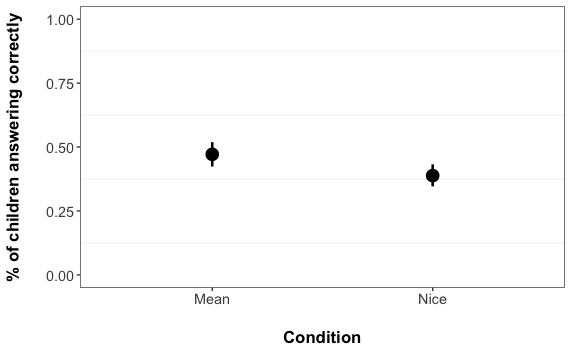

```r
ggplot(df_child_Sally, aes(y = Prop_correct, x = Nice_Mean)) +
  stat_summary(fun.data="mean_cl_boot", fun.args=list(B = 10000), na.rm=TRUE, position=position_dodge(width=0.3), size=1) +
  ylim (0,1) +
  ylab ("% of children answering correctly") +
  xlab ("Condition") +
  theme_bw() +
  theme(axis.text=element_text(size=12),
        axis.title=element_text(size=14,face="bold"),
        axis.title.y=element_text(margin=margin(r=20)),
        axis.title.x=element_text(margin=margin(t=20)),
        legend.text=element_text(size=12),
        legend.title=element_text(size=12,face="bold"),
        legend.key.size=unit(3, "lines"),
        strip.text=element_text(size=14, face="bold"),
        panel.grid.major.x=element_blank(),
        panel.grid.major.y=element_blank(),
        plot.title = element_text(hjust = 0.5))
```

##### (B) By condition and age

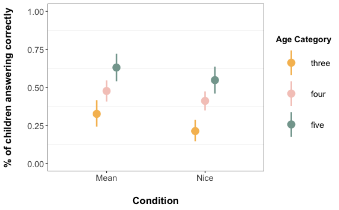

```r
ggplot(df_child_Sally, aes(y = Prop_correct, x = Nice_Mean, color= Age.Category)) +
  stat_summary(fun.data="mean_cl_boot", fun.args=list(B = 10000), na.rm=TRUE, position=position_dodge(width=0.3), size=1) +
  ylim (0,1) +
  ylab ("% of children answering correctly") +
  xlab ("Condition") +
  scale_color_manual(values = palette(), name="Age Category") +
  theme_bw() +
  theme(axis.text=element_text(size=12),
        axis.title=element_text(size=14,face="bold"),
        axis.title.y=element_text(margin=margin(r=20)),
        axis.title.x=element_text(margin=margin(t=20)),
        legend.text=element_text(size=12),
        legend.title=element_text(size=12,face="bold"),
        legend.key.size=unit(3, "lines"),
        strip.text=element_text(size=14, face="bold"),
        panel.grid.major.x=element_blank(),
        panel.grid.major.y=element_blank(),
        plot.title = element_text(hjust = 0.5))
```

#### Responses to Questions 3-5

##### (A) Should Anne and Sally be friends?

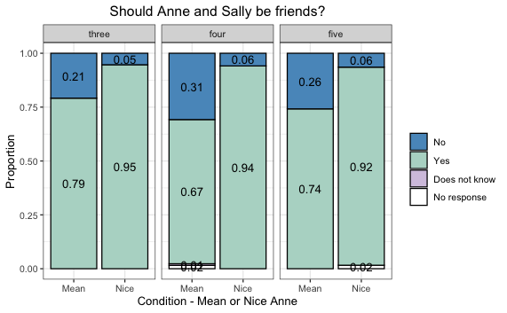

```r
t_friends <- df_child_Sally %>%
  group_by(Age.Category, Nice_Mean, Should.Anne.and.Sally.be.friends.) %>%
  dplyr::summarise(n = n())
t_friends <- left_join(t_friends, summarise_at(t_friends, vars(n), sum), by=c("Age.Category", "Nice_Mean")) %>%
  mutate(prop = n.x / n.y)

t_friends$Should.Anne.and.Sally.be.friends. <- factor(t_friends$Should.Anne.and.Sally.be.friends., levels=c("No","Yes","Does not know", "NA")) # specify order of level

ggplot(t_friends, aes(y=prop, x=Nice_Mean, fill=Should.Anne.and.Sally.be.friends.)) +
  geom_bar(stat="identity", colour="black") +
  geom_text(aes(label = round(prop, digits=2)), position=position_stack(vjust=0.5)) +
  facet_wrap(~Age.Category, ncol=3) +
  xlab("Condition - Mean or Nice Anne") +
  ylab("Proportion") +
  ggtitle("Should Anne and Sally be friends?") +
  scale_fill_manual(values = c("#5998c5","#b5d8cc", "#d5c6e0", "#ceeddb"), name="", labels=c("No", "Yes", "Does not know", "No response")) +
  theme_bw() +
  theme(plot.title = element_text(hjust = 0.5))
```

##### (B) Is Anne a nice girl or not a nice girl?

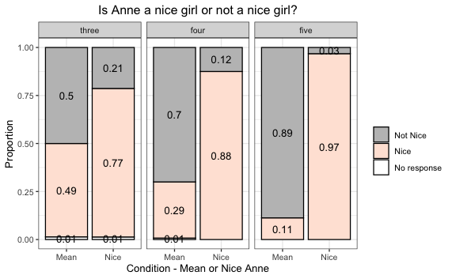

```r
t_anne <- df_child_Sally %>%
  group_by(Age.Category, Nice_Mean, Is.Anne.a.nice.girl.or.not.a.nice.girl) %>%
  dplyr::summarise(n = n())
t_anne <- left_join(t_anne, summarise_at(t_anne, vars(n), sum), by=c("Age.Category", "Nice_Mean")) %>%
  mutate(prop = n.x / n.y)

ggplot(t_anne, aes(y=prop, x=Nice_Mean, fill=Is.Anne.a.nice.girl.or.not.a.nice.girl)) +
  geom_bar(stat="identity", colour="black") +
  geom_text(aes(label = round(prop, digits=2)), position=position_stack(vjust=0.5)) +
  facet_wrap(~Age.Category, ncol=3) +
  xlab("Condition - Mean or Nice Anne") +
  ylab("Proportion") +
  ggtitle("Is Anne a nice girl or not a nice girl?") +
  scale_fill_manual(values = c("#bfbfbf", "#ffe5d9", "#4b5358"), name="", labels=c("Not Nice", "Nice", "No response")) +
  theme_bw() +
  theme(plot.title = element_text(hjust = 0.5))
```

##### (C) Is Sally a nice girl or not a nice girl?

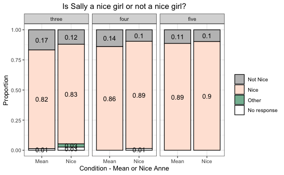

```r
t_sally <- df_child_Sally %>%
  group_by(Age.Category, Nice_Mean, Is.Sally.a.nice.girl.or.not.a.nice.girl.) %>%
  dplyr::summarise(n = n())
t_sally <- left_join(t_sally, summarise_at(t_sally, vars(n), sum), by=c("Age.Category", "Nice_Mean")) %>%
  mutate(prop = n.x / n.y)

ggplot(t_sally, aes(y=prop, x=Nice_Mean, fill=Is.Sally.a.nice.girl.or.not.a.nice.girl.)) +
  geom_bar(stat="identity", colour="black") +
  geom_text(aes(label = round(prop, digits=2)), position=position_stack(vjust=0.5)) +
  facet_wrap(~Age.Category, ncol=3) +
  xlab("Condition - Mean or Nice Anne") +
  ylab("Proportion") +
  ggtitle("Is Sally a nice girl or not a nice girl?") +
  scale_fill_manual(values = c("#bfbfbf", "#ffe5d9", "#85baa1", "#4b5358"), name="", labels=c("Not Nice", "Nice", "Other", "No response")) +
  theme_bw() +
  theme(plot.title = element_text(hjust = 0.5))
```

#### Figure S2. Performance by Question Type

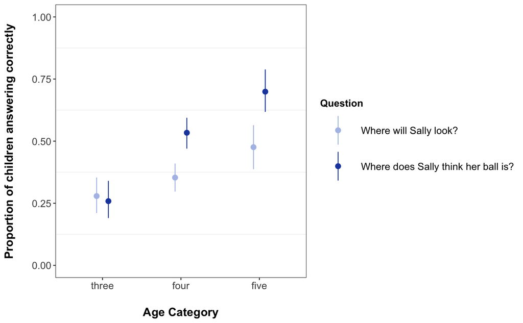

```r
ggplot(df_child_quest_Sally, aes(y = Correct, x = Age.Category, color= Question)) +
  stat_summary(fun.data="mean_cl_boot", position=position_dodge(0.3)) +
    ylim (0,1) +
    ylab ("Proportion of children answering correctly") +
    xlab ("Age Category") +
    scale_color_manual(values = c("#AFC0E8","#1F49AB"), labels = c("Where will Sally look?", "Where does Sally think her ball is?")) +
    theme_bw() +
    theme(axis.text=element_text(size=12),
          axis.title=element_text(size=14,face="bold"),
          axis.title.y=element_text(margin=margin(r=20)),
          axis.title.x=element_text(margin=margin(t=20)),
          legend.text=element_text(size=12),
          legend.title=element_text(size=12,face="bold"),
          legend.key.size=unit(3, "lines"),
          strip.text=element_text(size=14, face="bold"),
          panel.grid.major.x=element_blank(),
          panel.grid.major.y=element_blank(),
          plot.title = element_text(hjust = 0.5))
```

### Analyses

Variables we care about:

- Correct (Incorrect=0, Correct=1)
- Condition (Mean, Nice)
- Age Category (3s, 4s, 5s)
- Question Type (“Where will Sally look?”, “Where does Sally think her ball is?”)
- Is-Anne-Nice? (Mean, Nice)
- Counterbalancing Order (“Look” first, “Think” first)
- Gender (F,M)

The same analyses were performed for: - all usable data (“all”) - data from people responding to the question “Is Anne a nice girl or not a nice girl?” in a manner congruent with the condition to which they were assigned (“congruent”)

For both sets of data, we performed the same analyses using age as a categorical variable (Age Category) and age as a continuous variable (Age).

```r
var_dat <- c("all", "congruent")
var_age <- c("Age.Category", "Age_scaled")

for (d in var_dat) {
  if (exists("dat_model")) {rm(dat_model)}
  if (d == "all") {
    cat('\n\n*** All usable data ***\n\n')
    dat_model <- df_child_quest_Sally
  } else if (d == "congruent") {
    cat('\n\n*** Congruent data only ***\n\n')
    dat_model <- df_child_quest_congruent
  }
  for (a in var_age) {
    cat(paste0('\n\n--- Using the following age variable: ', a, ' ---\n\n'))
    dat_model$Age_model <- dat_model[,a]

    model <- glmer(Correct ~ Nice_Mean + Question + Age_model + Counterbalancing_order + Gender +
                    Nice_Mean:Question +
                    Nice_Mean:Age_model +
                    Nice_Mean:Counterbalancing_order +
                    Question:Age_model +
                    Nice_Mean:Question:Age_model +
                    (1 | Subject.Number),
                  data = dat_model,
                  family = binomial,
                  control = glmerControl(optimizer = 'optimx', optCtrl = list(method = 'bobyqa'))) # methods: nlminb, bobyqa

    # remove 3-way interaction
    model.1 <- update(model, . ~ . -Nice_Mean:Question:Age_model)
    print(drop1(model.1, test="Chisq"))
    # remove 2-way interactions with Condition
    model.2 <- update(model.1, . ~ . -Nice_Mean:Question -Nice_Mean:Age_model -Nice_Mean:Order.of.think.and.look.asked -Nice_Mean:Gender -Nice_Mean:Counterbalancing_order -Question:Counterbalancing_order)
    print(drop1(model.2, test="Chisq"))

    print(summary(model))
    print(tab_model(model, show.std = "std2", show.stat = TRUE, show.df = TRUE, file = paste0('model_1_', d, '_', a, '_fb.html')))

    if (a == "Age.Category") {
      cat("\n\nCondition by Age Category\n\n")
      print(emmeans(model, pairwise ~ Nice_Mean | Age_model, type="response")$contrast)
      cat("\nQuestion by Age Category\n\n")
      print(emmeans(model, pairwise ~ Question | Age_model, type="response")$contrast)
    }
    cat("\n\nCondition by Question Type\n\n")
    print(emmeans(model, pairwise ~ Nice_Mean | Question, type="response")$contrast)
    cat("\n\nCondition by Counterbalancing Order\n\n")
    print(emmeans(model, pairwise ~ Nice_Mean | Counterbalancing_order, type="response")$contrast)

  }
}
```

```
*** All usable data ***



--- Using the following age variable: Age.Category ---

Single term deletions

Model:
Correct ~ Nice_Mean + Question + Age_model + Counterbalancing_order +
    Gender + (1 | Subject.Number) + Nice_Mean:Question + Nice_Mean:Age_model +
    Nice_Mean:Counterbalancing_order + Question:Age_model
                                 Df    AIC     LRT  Pr(Chi)
<none>                              1345.0
Gender                            1 1344.5  1.5496 0.213188
Nice_Mean:Question                1 1344.5  1.5174 0.218015
Nice_Mean:Age_model               2 1341.8  0.8145 0.665491
Nice_Mean:Counterbalancing_order  1 1346.3  3.2658 0.070740 .
Question:Age_model                2 1351.9 10.8631 0.004376 **
---
Signif. codes:  0 ‘***’ 0.001 ‘**’ 0.01 ‘*’ 0.05 ‘.’ 0.1 ‘ ’ 1
Single term deletions

Model:
Correct ~ Nice_Mean + Question + Age_model + Counterbalancing_order +
    Gender + (1 | Subject.Number) + Question:Age_model
                       Df    AIC     LRT   Pr(Chi)
<none>                    1344.2
Nice_Mean               1 1349.4  7.1683  0.007420 **
Counterbalancing_order  1 1371.2 28.9789 7.317e-08 ***
Gender                  1 1343.8  1.6015  0.205697
Question:Age_model      2 1351.5 11.2868  0.003541 **
---
Signif. codes:  0 ‘***’ 0.001 ‘**’ 0.01 ‘*’ 0.05 ‘.’ 0.1 ‘ ’ 1
Generalized linear mixed model fit by maximum likelihood (Laplace Approximation) ['glmerMod']
 Family: binomial  ( logit )
Formula: Correct ~ Nice_Mean + Question + Age_model + Counterbalancing_order +
    Gender + Nice_Mean:Question + Nice_Mean:Age_model + Nice_Mean:Counterbalancing_order +
    Question:Age_model + Nice_Mean:Question:Age_model + (1 |      Subject.Number)
   Data: dat_model
```

[output cut: 18 more lines]

```
QuestionThink                               0.34039    0.22981   1.481  0.13855
Age_model.L                                 0.82656    0.32141   2.572  0.01012 *
Age_model.Q                                -0.04524    0.25852  -0.175  0.86107
Counterbalancing_ordersecond                0.58146    0.22006   2.642  0.00824 **
GenderM                                    -0.21547    0.17569  -1.226  0.22005
Nice_MeanNice:QuestionThink                 0.21109    0.32741   0.645  0.51910
Nice_MeanNice:Age_model.L                  -0.06732    0.45531  -0.148  0.88245
Nice_MeanNice:Age_model.Q                   0.22654    0.37445   0.605  0.54519
Nice_MeanNice:Counterbalancing_ordersecond  0.54633    0.31063   1.759  0.07862 .
QuestionThink:Age_model.L                   0.65803    0.41851   1.572  0.11587
QuestionThink:Age_model.Q                   0.09734    0.33496   0.291  0.77135
Nice_MeanNice:QuestionThink:Age_model.L     0.63880    0.60713   1.052  0.29273
Nice_MeanNice:QuestionThink:Age_model.Q    -0.77000    0.48663  -1.582  0.11358
---
Signif. codes:  0 ‘***’ 0.001 ‘**’ 0.01 ‘*’ 0.05 ‘.’ 0.1 ‘ ’ 1
```

```
Correlation matrix not shown by default, as p = 15 > 12.
Use print(summary(model), correlation=TRUE)  or
    vcov(summary(model))        if you need it
```

```
Condition by Age Category
```

```
NOTE: Results may be misleading due to involvement in interactions
```

```
Age_model = three:
 contrast    odds.ratio    SE  df z.ratio p.value
 Mean / Nice       2.14 0.762 Inf 2.145   0.0320

Age_model = four:
 contrast    odds.ratio    SE  df z.ratio p.value
 Mean / Nice       1.48 0.362 Inf 1.593   0.1112

Age_model = five:
 contrast    odds.ratio    SE  df z.ratio p.value
 Mean / Nice       1.50 0.544 Inf 1.121   0.2623

Results are averaged over the levels of: Question, Counterbalancing_order, Gender
Tests are performed on the log odds ratio scale

Question by Age Category
```

```
NOTE: Results may be misleading due to involvement in interactions
```

```
Age_model = three:
 contrast     odds.ratio    SE  df z.ratio p.value
 Look / Think      1.437 0.437 Inf  1.194  0.2326

Age_model = four:
 contrast     odds.ratio    SE  df z.ratio p.value
 Look / Think      0.506 0.109 Inf -3.165  0.0016

Age_model = five:
 contrast     odds.ratio    SE  df z.ratio p.value
 Look / Think      0.361 0.113 Inf -3.260  0.0011

Results are averaged over the levels of: Nice_Mean, Counterbalancing_order, Gender
Tests are performed on the log odds ratio scale


Condition by Question Type
```

```
NOTE: Results may be misleading due to involvement in interactions
```

```
Question = Look:
 contrast    odds.ratio    SE  df z.ratio p.value
 Mean / Nice       1.87 0.459 Inf 2.545   0.0109

Question = Think:
 contrast    odds.ratio    SE  df z.ratio p.value
 Mean / Nice       1.51 0.385 Inf 1.627   0.1038

Results are averaged over the levels of: Age_model, Counterbalancing_order, Gender
Tests are performed on the log odds ratio scale


Condition by Counterbalancing Order

Counterbalancing_order = first:
 contrast    odds.ratio    SE  df z.ratio p.value
 Mean / Nice       2.21 0.554 Inf 3.160   0.0016

Counterbalancing_order = second:
 contrast    odds.ratio    SE  df z.ratio p.value
 Mean / Nice       1.28 0.305 Inf 1.034   0.3012

Results are averaged over the levels of: Question, Age_model, Gender
Tests are performed on the log odds ratio scale


--- Using the following age variable: Age_scaled ---

Single term deletions

Model:
Correct ~ Nice_Mean + Question + Age_model + Counterbalancing_order +
    Gender + (1 | Subject.Number) + Nice_Mean:Question + Nice_Mean:Age_model +
    Nice_Mean:Counterbalancing_order + Question:Age_model
                                 Df    AIC     LRT   Pr(Chi)
<none>                              1332.0
Gender                            1 1331.5  1.5151 0.2183562
Nice_Mean:Question                1 1331.7  1.7553 0.1852060
Nice_Mean:Age_model               1 1330.7  0.7475 0.3872819
Nice_Mean:Counterbalancing_order  1 1333.5  3.5551 0.0593625 .
```

[output cut: 52 more lines]

```
Correlation of Fixed Effects:
            (Intr) Nc_MnN QstnTh Ag_mdl Cntrb_ GendrM Nc_MN:QT N_MN:A N_MN:C QsT:A_
Nice_MeanNc -0.557
QuestinThnk -0.381  0.264
Age_model   -0.222  0.120  0.143
Cntrblncng_ -0.393  0.246 -0.305  0.066
GenderM     -0.418  0.023 -0.002 -0.035 -0.019
Nc_MnNc:QsT  0.251 -0.440 -0.694 -0.082  0.230 -0.012
Nc_MnNc:Ag_  0.143 -0.229 -0.094 -0.686 -0.030  0.006  0.148
Nc_MnNc:Cn_  0.243 -0.467  0.229 -0.012 -0.674 -0.006 -0.259    0.035
QstnThnk:A_  0.116 -0.111 -0.186 -0.598 -0.007 -0.012  0.139    0.430  0.022
Nc_MN:QT:A_ -0.101  0.114  0.136  0.433  0.025 -0.004 -0.211   -0.625  0.029 -0.678


Condition by Question Type
```

```
NOTE: Results may be misleading due to involvement in interactions
```

```
Question = Look:
 contrast    odds.ratio    SE  df z.ratio p.value
 Mean / Nice       1.91 0.446 Inf 2.768   0.0056

Question = Think:
 contrast    odds.ratio    SE  df z.ratio p.value
 Mean / Nice       1.29 0.301 Inf 1.096   0.2729

Results are averaged over the levels of: Counterbalancing_order, Gender
Tests are performed on the log odds ratio scale


Condition by Counterbalancing Order

Counterbalancing_order = first:
 contrast    odds.ratio    SE  df z.ratio p.value
 Mean / Nice       2.11 0.506 Inf 3.104   0.0019

Counterbalancing_order = second:
 contrast    odds.ratio    SE  df z.ratio p.value
 Mean / Nice       1.17 0.266 Inf 0.689   0.4907

Results are averaged over the levels of: Question, Gender
Tests are performed on the log odds ratio scale


*** Congruent data only ***



--- Using the following age variable: Age.Category ---

Single term deletions

Model:
Correct ~ Nice_Mean + Question + Age_model + Counterbalancing_order +
    Gender + (1 | Subject.Number) + Nice_Mean:Question + Nice_Mean:Age_model +
    Nice_Mean:Counterbalancing_order + Question:Age_model
                                 Df    AIC    LRT Pr(Chi)
<none>                              1049.5
```

[output cut: 44 more lines]

```
QuestionThink                               0.45733    0.27210   1.681   0.0928 .
Age_model.L                                 0.64184    0.38049   1.687   0.0916 .
Age_model.Q                                -0.17712    0.30249  -0.586   0.5582
Counterbalancing_ordersecond                0.46122    0.25618   1.800   0.0718 .
GenderM                                    -0.40055    0.19272  -2.078   0.0377 *
Nice_MeanNice:QuestionThink                 0.31288    0.36953   0.847   0.3972
Nice_MeanNice:Age_model.L                   0.24540    0.51899   0.473   0.6363
Nice_MeanNice:Age_model.Q                   0.25934    0.41889   0.619   0.5358
Nice_MeanNice:Counterbalancing_ordersecond  0.62370    0.34664   1.799   0.0720 .
QuestionThink:Age_model.L                   0.43924    0.49724   0.883   0.3770
QuestionThink:Age_model.Q                   0.09716    0.39646   0.245   0.8064
Nice_MeanNice:QuestionThink:Age_model.L     0.70651    0.69172   1.021   0.3071
Nice_MeanNice:QuestionThink:Age_model.Q    -0.71888    0.54853  -1.311   0.1900
---
Signif. codes:  0 ‘***’ 0.001 ‘**’ 0.01 ‘*’ 0.05 ‘.’ 0.1 ‘ ’ 1
```

```
Correlation matrix not shown by default, as p = 15 > 12.
Use print(summary(model), correlation=TRUE)  or
    vcov(summary(model))        if you need it
```

```
Condition by Age Category
```

```
NOTE: Results may be misleading due to involvement in interactions
```

```
Age_model = three:
 contrast    odds.ratio    SE  df z.ratio p.value
 Mean / Nice       3.45 1.508 Inf 2.838   0.0045

Age_model = four:
 contrast    odds.ratio    SE  df z.ratio p.value
 Mean / Nice       2.00 0.539 Inf 2.572   0.0101

Age_model = five:
 contrast    odds.ratio    SE  df z.ratio p.value
 Mean / Nice       1.48 0.534 Inf 1.089   0.2762

Results are averaged over the levels of: Question, Counterbalancing_order, Gender
Tests are performed on the log odds ratio scale

Question by Age Category
```

```
NOTE: Results may be misleading due to involvement in interactions
```

```
Age_model = three:
 contrast     odds.ratio    SE  df z.ratio p.value
 Look / Think      1.055 0.398 Inf  0.142  0.8868

Age_model = four:
 contrast     odds.ratio    SE  df z.ratio p.value
 Look / Think      0.437 0.105 Inf -3.432  0.0006

Age_model = five:
 contrast     odds.ratio    SE  df z.ratio p.value
 Look / Think      0.344 0.110 Inf -3.323  0.0009

Results are averaged over the levels of: Nice_Mean, Counterbalancing_order, Gender
Tests are performed on the log odds ratio scale


Condition by Question Type
```

```
NOTE: Results may be misleading due to involvement in interactions
```

```
Question = Look:
 contrast    odds.ratio    SE  df z.ratio p.value
 Mean / Nice       2.54 0.712 Inf 3.322   0.0009

Question = Think:
 contrast    odds.ratio    SE  df z.ratio p.value
 Mean / Nice       1.86 0.524 Inf 2.192   0.0284

Results are averaged over the levels of: Age_model, Counterbalancing_order, Gender
Tests are performed on the log odds ratio scale


Condition by Counterbalancing Order

Counterbalancing_order = first:
 contrast    odds.ratio    SE  df z.ratio p.value
 Mean / Nice       2.97 0.834 Inf 3.867   0.0001

Counterbalancing_order = second:
 contrast    odds.ratio    SE  df z.ratio p.value
 Mean / Nice       1.59 0.424 Inf 1.737   0.0824

Results are averaged over the levels of: Question, Age_model, Gender
Tests are performed on the log odds ratio scale


--- Using the following age variable: Age_scaled ---

Single term deletions

Model:
Correct ~ Nice_Mean + Question + Age_model + Counterbalancing_order +
    Gender + (1 | Subject.Number) + Nice_Mean:Question + Nice_Mean:Age_model +
    Nice_Mean:Counterbalancing_order + Question:Age_model
                                 Df    AIC    LRT Pr(Chi)
<none>                              1039.2
Gender                            1 1042.2 5.0183 0.02508 *
Nice_Mean:Question                1 1039.8 2.5990 0.10693
Nice_Mean:Age_model               1 1038.6 1.4346 0.23102
Nice_Mean:Counterbalancing_order  1 1040.6 3.4599 0.06287 .
```

[output cut: 52 more lines]

```
Correlation of Fixed Effects:
            (Intr) Nc_MnN QstnTh Ag_mdl Cntrb_ GendrM Nc_MN:QT N_MN:A N_MN:C QsT:A_
Nice_MeanNc -0.630
QuestinThnk -0.420  0.294
Age_model   -0.362  0.242  0.260
Cntrblncng_ -0.373  0.252 -0.270  0.067
GenderM     -0.393  0.071 -0.017 -0.048 -0.023
Nc_MnNc:QsT  0.311 -0.477 -0.736 -0.175  0.217 -0.019
Nc_MnNc:Ag_  0.271 -0.351 -0.183 -0.727 -0.037 -0.001  0.245
Nc_MnNc:Cn_  0.266 -0.458  0.218 -0.021 -0.717 -0.022 -0.229    0.038
QstnThnk:A_  0.239 -0.193 -0.354 -0.624 -0.039 -0.011  0.270    0.468  0.037
Nc_MN:QT:A_ -0.183  0.194  0.269  0.472  0.041 -0.008 -0.333   -0.643  0.019 -0.726


Condition by Question Type
```

```
NOTE: Results may be misleading due to involvement in interactions
```

```
Question = Look:
 contrast    odds.ratio    SE  df z.ratio p.value
 Mean / Nice       2.56 0.671 Inf 3.586   0.0003

Question = Think:
 contrast    odds.ratio    SE  df z.ratio p.value
 Mean / Nice       1.50 0.384 Inf 1.571   0.1161

Results are averaged over the levels of: Counterbalancing_order, Gender
Tests are performed on the log odds ratio scale


Condition by Counterbalancing Order

Counterbalancing_order = first:
 contrast    odds.ratio    SE  df z.ratio p.value
 Mean / Nice       2.70 0.718 Inf 3.736   0.0002

Counterbalancing_order = second:
 contrast    odds.ratio    SE  df z.ratio p.value
 Mean / Nice       1.42 0.360 Inf 1.379   0.1680

Results are averaged over the levels of: Question, Gender
Tests are performed on the log odds ratio scale
```

## Study 2

### Study 2 combining Study 2a and 2b

#### Descriptives

##### Sample demographics

```r
print("With no exclusions")
```

```
[1] "With no exclusions"
```

```r
dem_noexcl <- subset(df_adults_dem, condition == "attention") %>% distinct_at(c("ResponseId", "Age", "Gender"))

summary(dem_noexcl[c("Age", "Gender")])
```

```
      Age           Gender
 Min.   :19.00   Female: 73
 1st Qu.:29.00   Male  :116
 Median :33.00   Other :  0
 Mean   :36.62
 3rd Qu.:42.00
 Max.   :66.00
```

```r
print("With exclusions")
```

```
[1] "With exclusions"
```

```r
dem <- subset(df_adults_dem, condition == "attention" & correct == TRUE) %>% distinct_at(c("ResponseId", "Age", "Gender"))

summary(dem[c("Age", "Gender")])
```

```
      Age           Gender
 Min.   :19.00   Female: 68
 1st Qu.:29.00   Male  :111
 Median :34.00   Other :  0
 Mean   :36.85
 3rd Qu.:43.00
 Max.   :66.00
```

##### By condition

```r
dem_by_subj <- summarySE(subset(df_adults_long, version == "2a" | version == "2b"), measurevar = "correct", groupvars = c("ResponseId", "condition"))
with(dem_by_subj, table(condition))
```

```
condition
   mean    nice neutral
    189     189     189
```

```r
dem_count <- count(dem_by_subj, vars = c("correct", "condition"))
dem_count
```

| correct | condition | freq |
| --- | --- | --- |
| 0.2 | mean | 1 |
| 0.2 | neutral | 1 |
| 0.3 | mean | 3 |
| 0.3 | nice | 3 |
| 0.3 | neutral | 6 |
| 0.4 | mean | 7 |
| 0.4 | nice | 7 |
| 0.4 | neutral | 4 |
| 0.5 | mean | 9 |
| 0.5 | nice | 7 |

[output cut: 16 more lines]

```r
sum(dem_count$freq)
```

```
[1] 567
```

##### Figure 2. Condition differences

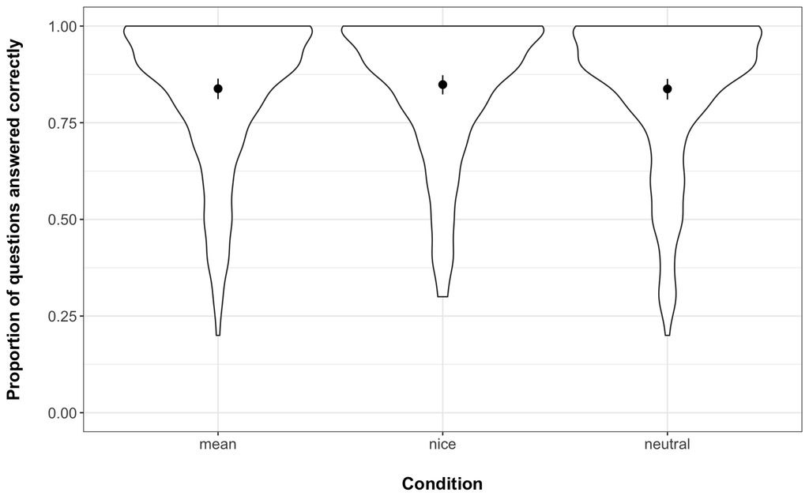

```r
df_adults_plot <- summarySE(subset(df_adults_long, version == "2a" | version == "2b"), measurevar = "correct", groupvars = c("ResponseId", "condition"))

ggplot(df_adults_plot, aes(y = correct, x = condition)) +
  geom_violin() +
  stat_summary(fun.data="mean_cl_boot", fun.args=list(B = 10000), na.rm=TRUE, position=position_dodge(width=0.3), size=0.5) +
  ylim (0,1) +
  ylab ("Proportion of questions answered correctly") +
  xlab ("Condition") +
  theme_bw() +
  theme(axis.text=element_text(size=12),
        axis.title=element_text(size=14,face="bold"),
        axis.title.y=element_text(margin=margin(r=20)),
        axis.title.x=element_text(margin=margin(t=20)),
        legend.text=element_text(size=12),
        legend.title=element_text(size=12,face="bold"),
        legend.key.size=unit(3, "lines"),
        plot.title = element_text(hjust = 0.5))
```

#### Analyses

##### With the two full versions

###### Response on the false belief question

```r
m2_full <- glmer(correct ~ condition + Gender + Age +
                    (1|ResponseId) + (1|item),
                  data=subset(df_adults_long, version == "2a" | version == "2b"),
                  family=binomial,
                  control = glmerControl(optimizer = 'optimx', optCtrl = list(method = 'bobyqa'))) # methods: nlminb, bobyqa

m3_full <- update(m2_full, . ~ . -condition)

anova(m2_full, m3_full, test="Chisq")
```

```
Data: subset(df_adults_long, version == "2a" | version == "2b")
Models:
m3_full: correct ~ Gender + Age + (1 | ResponseId) + (1 | item)
m2_full: correct ~ condition + Gender + Age + (1 | ResponseId) + (1 |
m2_full:     item)
        Df    AIC    BIC  logLik deviance  Chisq Chi Df Pr(>Chisq)
m3_full  5 4047.6 4080.8 -2018.8   4037.6
m2_full  7 4049.6 4096.1 -2017.8   4035.6 2.0067      2     0.3667
```

```r
print(summary(m2_full))
```

```
Generalized linear mixed model fit by maximum likelihood (Laplace Approximation) ['glmerMod']
 Family: binomial  ( logit )
Formula: correct ~ condition + Gender + Age + (1 | ResponseId) + (1 |      item)
   Data: subset(df_adults_long, version == "2a" | version == "2b")
Control: glmerControl(optimizer = "optimx", optCtrl = list(method = "bobyqa"))

     AIC      BIC   logLik deviance df.resid
  4049.6   4096.1  -2017.8   4035.6     5663

Scaled residuals:
    Min      1Q  Median      3Q     Max
-5.5891  0.1397  0.2296  0.3635  2.9307

Random effects:
 Groups     Name        Variance Std.Dev.
 ResponseId (Intercept) 1.5483   1.2443
 item       (Intercept) 0.5857   0.7653
Number of obs: 5670, groups:  ResponseId, 189; item, 30

Fixed effects:
                  Estimate Std. Error z value Pr(>|z|)
(Intercept)       0.387220   0.442788   0.875    0.382
conditionnice     0.123909   0.101674   1.219    0.223
conditionneutral -0.008281   0.100170  -0.083    0.934
GenderMale       -0.040938   0.213621  -0.192    0.848
Age               0.053447   0.010163   5.259 1.45e-07 ***
---
Signif. codes:  0 ‘***’ 0.001 ‘**’ 0.01 ‘*’ 0.05 ‘.’ 0.1 ‘ ’ 1

Correlation of Fixed Effects:
            (Intr) cndtnnc cndtnnt GndrMl
conditionnc -0.114
conditnntrl -0.112  0.493
GenderMale  -0.407  0.002  -0.003
Age         -0.858  0.004   0.000   0.130
```

```r
print(tab_model(m2_full, show.std = "std2", show.stat = TRUE, show.df = TRUE, file = paste0('model_2ab_fb.html')))

print(emmeans(m2_full, pairwise ~ condition, type="response")$contrast)
```

```
 contrast       odds.ratio     SE  df z.ratio p.value
 mean / nice         0.883 0.0898 Inf -1.219  0.4421
 mean / neutral      1.008 0.1010 Inf  0.083  0.9962
 nice / neutral      1.141 0.1160 Inf  1.300  0.3949

Results are averaged over the levels of: Gender
P value adjustment: tukey method for comparing a family of 3 estimates
Tests are performed on the log odds ratio scale
```

###### Sensitivity analysis

```r
# Sensitivity power analysis for the fixed N.
# Estimating the power to detect ES from .4 to .48 for the effect of condition
N <- 279

es.vect <- c(.28, .29, .30)
pwr <- NA
m_sensitive1 <- m2_full
m_sensitive2 <- m3_full
for(i in 1:length(es.vect)){
  fixef(m_sensitive1)["conditionnice"] <- es.vect[i]
  pwr[i] <- round(as.numeric(summary(powerSim(m_sensitive1, test = compare(m_sensitive2, method = "lr"), nsim = 1000)))[3],3)
  print(pwr[i])
}
```

[output not shown]

###### RT for false belief question

```r
m2_full_RT <- lmer(TF_RT ~ condition + Gender + Age +
                    (1|ResponseId) + (1|item),
                  data=subset(df_adults_long, version == "2a" | version == "2b"))

print(summary(m2_full_RT))
```

```
Linear mixed model fit by REML ['lmerMod']
Formula: TF_RT ~ condition + Gender + Age + (1 | ResponseId) + (1 | item)
   Data: subset(df_adults_long, version == "2a" | version == "2b")

REML criterion at convergence: 49837.4

Scaled residuals:
   Min     1Q Median     3Q    Max
-2.013 -0.094 -0.053 -0.003 48.261

Random effects:
 Groups     Name        Variance Std.Dev.
 ResponseId (Intercept)  22.4656  4.7398
 item       (Intercept)   0.6169  0.7854
 Residual               371.1234 19.2646
Number of obs: 5670, groups:  ResponseId, 189; item, 30

Fixed effects:
                  Estimate Std. Error t value
(Intercept)       4.443876   1.752785   2.535
conditionnice    -0.598706   0.627084  -0.955
conditionneutral -0.882401   0.627160  -1.407
GenderMale        0.491659   0.888051   0.554
Age               0.001229   0.040914   0.030

Correlation of Fixed Effects:
            (Intr) cndtnnc cndtnnt GndrMl
conditionnc -0.179
conditnntrl -0.179  0.500
GenderMale  -0.412  0.000   0.000
Age         -0.892  0.000   0.000   0.119
```

```r
print(tab_model(m2_full_RT, show.std = "std2", show.stat = TRUE, show.df = TRUE, file = paste0('model_2ab_fb_RT.html')))

drop1(m2_full_RT, test="Chisq")
```

```
Single term deletions

Model:
TF_RT ~ condition + Gender + Age + (1 | ResponseId) + (1 | item)
          Df   AIC     LRT Pr(Chi)
<none>       49852
condition  2 49850 2.06404  0.3563
Gender     1 49851 0.31104  0.5770
Age        1 49850 0.00092  0.9759
```

###### Removing ceiling performance

Response on the false belief question

```r
df_adults_noceil <- df_adults_long %>% filter(version == "2a" | version == "2b") %>% group_by(ResponseId, condition) %>% dplyr::mutate(correct_prop = mean(correct)) %>% ungroup() %>% filter(correct_prop != 1)

m2_full_noceil <- glmer(correct ~ condition + Gender + Age +
                    (1|ResponseId) + (1|item),
                  data=df_adults_noceil,
                  family=binomial,
                  control = glmerControl(optimizer = 'optimx', optCtrl = list(method = 'bobyqa'))) # methods: nlminb, bobyqa

anova(m2_full_noceil, update(m2_full_noceil, . ~ . -condition), test="Chisq")
```

```
Data: df_adults_noceil
Models:
update(m2_full_noceil, . ~ . - condition): correct ~ Gender + Age + (1 | ResponseId) + (1 | item)
m2_full_noceil: correct ~ condition + Gender + Age + (1 | ResponseId) + (1 |
m2_full_noceil:     item)
                                          Df    AIC    BIC  logLik deviance  Chisq Chi Df Pr(>Chisq)
update(m2_full_noceil, . ~ . - condition)  5 3650.8 3681.8 -1820.4   3640.8
m2_full_noceil                             7 3654.1 3697.6 -1820.0   3640.1 0.6577      2     0.7197
```

```r
print(summary(m2_full_noceil))
```

```
Generalized linear mixed model fit by maximum likelihood (Laplace Approximation) ['glmerMod']
 Family: binomial  ( logit )
Formula: correct ~ condition + Gender + Age + (1 | ResponseId) + (1 |      item)
   Data: df_adults_noceil
Control: glmerControl(optimizer = "optimx", optCtrl = list(method = "bobyqa"))

     AIC      BIC   logLik deviance df.resid
  3654.1   3697.6  -1820.1   3640.1     3663

Scaled residuals:
    Min      1Q  Median      3Q     Max
-4.6137  0.2056  0.3687  0.5117  2.5447

Random effects:
 Groups     Name        Variance Std.Dev.
 ResponseId (Intercept) 0.6121   0.7824
 item       (Intercept) 0.5583   0.7472
Number of obs: 3670, groups:  ResponseId, 169; item, 30

Fixed effects:
                  Estimate Std. Error z value Pr(>|z|)
(Intercept)       0.474715   0.351074   1.352 0.176318
conditionnice     0.075949   0.108734   0.698 0.484872
conditionneutral -0.003455   0.106179  -0.033 0.974043
GenderMale        0.082874   0.160783   0.515 0.606243
Age               0.028259   0.007945   3.557 0.000376 ***
---
Signif. codes:  0 ‘***’ 0.001 ‘**’ 0.01 ‘*’ 0.05 ‘.’ 0.1 ‘ ’ 1

Correlation of Fixed Effects:
            (Intr) cndtnnc cndtnnt GndrMl
conditionnc -0.134
conditnntrl -0.121  0.490
GenderMale  -0.409  0.007  -0.018
Age         -0.827 -0.018  -0.031   0.153
```

```r
print(tab_model(m2_full_noceil, show.std = "std2", show.stat = TRUE, show.df = TRUE, file = paste0('model_2ab_fb_noceil.html')))

print(emmeans(m2_full_noceil, pairwise ~ condition, type="response")$contrast)
```

```
 contrast       odds.ratio    SE  df z.ratio p.value
 mean / nice         0.927 0.101 Inf -0.698  0.7644
 mean / neutral      1.003 0.107 Inf  0.033  0.9994
 nice / neutral      1.083 0.118 Inf  0.731  0.7448

Results are averaged over the levels of: Gender
P value adjustment: tukey method for comparing a family of 3 estimates
Tests are performed on the log odds ratio scale
```

## Study 2-pre (Supp Mat)

### Descriptives

#### Sample demographics

```r
print("With no exclusions")
```

```
[1] "With no exclusions"
```

```r
dem_2pre_noexcl <- subset(df_adults_dem, version == "pre" & condition == "nice") %>% distinct_at(c("ResponseId", "Age", "Gender"))

summary(dem_2pre_noexcl[c("Age", "Gender")])
```

```
      Age         Gender
 Min.   : NA   Female:0
 1st Qu.: NA   Male  :0
 Median : NA   Other :0
 Mean   :NaN
 3rd Qu.: NA
 Max.   : NA
```

### Analyses

#### Manipulation check

```r
df_adults_2pre_m <- subset(df_adults_2pre, !is.na(condition) & !is.na(Gender) & !is.na(Age) & !is.na(ResponseId) & !is.na(item) & !is.na(Nice))

m2pre_full_check <- clmm(Nice ~ condition + Gender + Age +
                    (1|ResponseId) + (1|item),
                  data=df_adults_2pre_m)

drop1(m2pre_full_check, test="Chisq")
```

```
Single term deletions

Model:
Nice ~ condition + Gender + Age + (1 | ResponseId) + (1 | item)
          Df    AIC    LRT Pr(>Chi)
<none>       5208.7
condition  2 5615.3 410.62   <2e-16 ***
Gender     2 5206.0   1.32   0.5174
Age        1 5208.5   1.80   0.1799
---
Signif. codes:  0 ‘***’ 0.001 ‘**’ 0.01 ‘*’ 0.05 ‘.’ 0.1 ‘ ’ 1
```

```r
print(emmeans(m2pre_full_check, pairwise ~ condition, type="response")$contrast, mode="mean.class")
```

```
 contrast       estimate    SE  df z.ratio p.value
 mean - nice       -2.48 0.132 Inf -18.829 <.0001
 mean - neutral    -1.12 0.119 Inf  -9.406 <.0001
 nice - neutral     1.37 0.104 Inf  13.097 <.0001

Results are averaged over the levels of: Gender
P value adjustment: tukey method for comparing a family of 3 estimates
```

#### Response on false belief question

```r
df_adults_2pre_m <- subset(df_adults_2pre, !is.na(condition) & !is.na(Gender) & !is.na(Age) & !is.na(ResponseId) & !is.na(item) & !is.na(correct))

m2pre_full <- glmer(correct ~ condition + Gender + Age +
                    (1|ResponseId) + (1|item),
                  data=df_adults_2pre_m,
                  family=binomial,
                  control = glmerControl(optimizer = 'optimx', optCtrl = list(method = 'bobyqa'))) # methods: nlminb, bobyqa

drop1(m2pre_full, test="Chisq")
```

```
Single term deletions

Model:
correct ~ condition + Gender + Age + (1 | ResponseId) + (1 |
    item)
          Df    AIC    LRT Pr(Chi)
<none>       2229.4
condition  2 2227.3 1.8246 0.40161
Gender     2 2227.3 1.8859 0.38947
Age        1 2233.2 5.7307 0.01667 *
---
Signif. codes:  0 ‘***’ 0.001 ‘**’ 0.01 ‘*’ 0.05 ‘.’ 0.1 ‘ ’ 1
```

```r
print(summary(m2pre_full))
```

```
Generalized linear mixed model fit by maximum likelihood (Laplace Approximation) ['glmerMod']
 Family: binomial  ( logit )
Formula: correct ~ condition + Gender + Age + (1 | ResponseId) + (1 |      item)
   Data: df_adults_2pre_m
Control: glmerControl(optimizer = "optimx", optCtrl = list(method = "bobyqa"))

     AIC      BIC   logLik deviance df.resid
  2229.4   2276.3  -1106.7   2213.4     2572

Scaled residuals:
    Min      1Q  Median      3Q     Max
-5.2955  0.1719  0.2921  0.4556  1.9034

Random effects:
 Groups     Name        Variance Std.Dev.
 ResponseId (Intercept) 1.262    1.1235
 item       (Intercept) 0.387    0.6221
Number of obs: 2580, groups:  ResponseId, 86; item, 30

Fixed effects:
                 Estimate Std. Error z value Pr(>|z|)
(Intercept)       0.46097    0.53095   0.868   0.3853
conditionnice     0.18527    0.13495   1.373   0.1698
conditionneutral  0.10207    0.13335   0.765   0.4440
GenderMale        0.39227    0.28338   1.384   0.1663
GenderOther       0.23379    1.25372   0.186   0.8521
Age               0.03064    0.01269   2.414   0.0158 *
---
Signif. codes:  0 ‘***’ 0.001 ‘**’ 0.01 ‘*’ 0.05 ‘.’ 0.1 ‘ ’ 1

Correlation of Fixed Effects:
            (Intr) cndtnnc cndtnnt GndrMl GndrOt
conditionnc -0.120
conditnntrl -0.118  0.482
GenderMale  -0.420  0.001  -0.004
GenderOther -0.105  0.002  -0.001   0.140
Age         -0.872  0.000  -0.004   0.114  0.036
```

```r
print(tab_model(m2pre_full, show.std = "std2", show.stat = TRUE, show.df = TRUE, file = paste0('model_2pre_fb.html')))

print(emmeans(m2pre_full, pairwise ~ condition, type="response")$contrast)
```

```
 contrast       odds.ratio    SE  df z.ratio p.value
 mean / nice         0.831 0.112 Inf -1.373  0.3552
 mean / neutral      0.903 0.120 Inf -0.765  0.7243
 nice / neutral      1.087 0.148 Inf  0.609  0.8151

Results are averaged over the levels of: Gender
P value adjustment: tukey method for comparing a family of 3 estimates
Tests are performed on the log odds ratio scale
```

#### RT for false belief question

```r
df_adults_2pre_m <- subset(df_adults_2pre, !is.na(condition) & !is.na(Gender) & !is.na(Age) & !is.na(ResponseId) & !is.na(item) & !is.na(TF_RT))

m2pre_full_RT <- lmer(TF_RT ~ condition + Gender + Age +
                    (1|ResponseId) + (1|item),
                  data=df_adults_2pre_m)

print(summary(m2pre_full_RT))
```

```
Linear mixed model fit by REML ['lmerMod']
Formula: TF_RT ~ condition + Gender + Age + (1 | ResponseId) + (1 | item)
   Data: df_adults_2pre_m

REML criterion at convergence: 16916.9

Scaled residuals:
    Min      1Q  Median      3Q     Max
-2.2371 -0.2244 -0.0880  0.0436 21.0460

Random effects:
 Groups     Name        Variance Std.Dev.
 ResponseId (Intercept) 10.6025  3.2561
 item       (Intercept)  0.1833  0.4282
 Residual               38.1956  6.1803
Number of obs: 2580, groups:  ResponseId, 86; item, 30

Fixed effects:
                 Estimate Std. Error t value
(Intercept)       2.18260    1.37747   1.584
conditionnice     0.15865    0.29827   0.532
conditionneutral  0.12916    0.29843   0.433
GenderMale        0.22192    0.77348   0.287
GenderOther      -1.42709    3.50169  -0.408
Age               0.04539    0.03328   1.364

Correlation of Fixed Effects:
            (Intr) cndtnnc cndtnnt GndrMl GndrOt
conditionnc -0.108
conditnntrl -0.108  0.500
GenderMale  -0.412  0.000   0.000
GenderOther -0.108  0.000   0.000   0.140
Age         -0.886  0.000   0.000   0.072  0.035
```

```r
print(tab_model(m2pre_full_RT, show.std = "std2", show.stat = TRUE, show.df = TRUE, file = paste0('model_2pre_fb_RT.html')))

drop1(m2pre_full_RT, test="Chisq")
```

```
Single term deletions

Model:
TF_RT ~ condition + Gender + Age + (1 | ResponseId) + (1 | item)
          Df   AIC     LRT Pr(Chi)
<none>       16934
condition  2 16930 0.32009  0.8521
Gender     2 16930 0.29994  0.8607
Age        1 16934 1.92810  0.1650
```

```r
print(emmeans(m2pre_full_RT, pairwise ~ condition, type="response")$contrast)
```

```
 contrast       estimate    SE   df t.ratio p.value
 mean - nice     -0.1587 0.298 2479 -0.532  0.8557
 mean - neutral  -0.1292 0.299 2486 -0.433  0.9020
 nice - neutral   0.0295 0.299 2488  0.099  0.9946

Results are averaged over the levels of: Gender
Degrees-of-freedom method: kenward-roger
P value adjustment: tukey method for comparing a family of 3 estimates
```